# Data Science Capstone Week 2 Assignment

Grejell Segura

June 18, 2018

## Overview

This document aims to show a simple exploratory data analysis about the news, blogs and twitter data.

```r
rm(list = ls())
library(data.table)
library(tidyverse)
library(tidytext)
library(dplyr)
library(ggplot2)
```

### Loading the Data

The data was preloaded in another script shown in the Appendix below. Checking the summary of the data.

```r
load("./dta/textDta.RData")
summary(textDta)
```

```
##                       text            source
##  Thanks for the RT!     :    571   Length:3336695
##  Thank you!             :    547   Class :character
##  thank you!             :    382   Mode  :character
##  Thanks for the follow! :    326
##  Thanks for the mention!:    188
##  thanks for the RT!     :    185
##  (Other)                :3334496
```

```r
summary(as.factor(textDta$source))
```

```
##    blog    news twitter
##  899288   77259 2360148
```

Since the the data is too big to process, we will only use 5% of the observations which are randomly selected. Below are the distribution of the samples per source.

```r
textDta <- textDta[sample(1:nrow(textDta), 0.05*nrow(textDta)),]
summary(as.factor(textDta$source))
```

```
##    blog    news twitter
##   45309    3847  117678
```

### Stop Words

Depending on the type of analysis, stop words are used to exclude the words that are very common. In this project, I used the pre-existing stop words data called “stop_words”. The data summary is shown below.

```
## Classes 'tbl_df', 'tbl' and 'data.frame':    1149 obs. of  2 variables:
##  $ word   : chr  "a" "a's" "able" "about" ...
##  $ lexicon: chr  "SMART" "SMART" "SMART" "SMART" ...
```

There are 1,149 words listed in the stop words which we will use in the following data exploration.

### Tokenization of the Data

Tokenization is the process of breaking up a sequence of strings into words or phrases. The term used to determine the number of sequence of words in tokenization is “n-gram”. The “n” describes the number of words in the sequence. Here we will explore different sequences, 1-gram, 2-gram and 3-gram.

The following are the top 20 1-gram, 2-gram and 3-grams. It is important to note that this is a sample and a margin error should be considered when analysing.

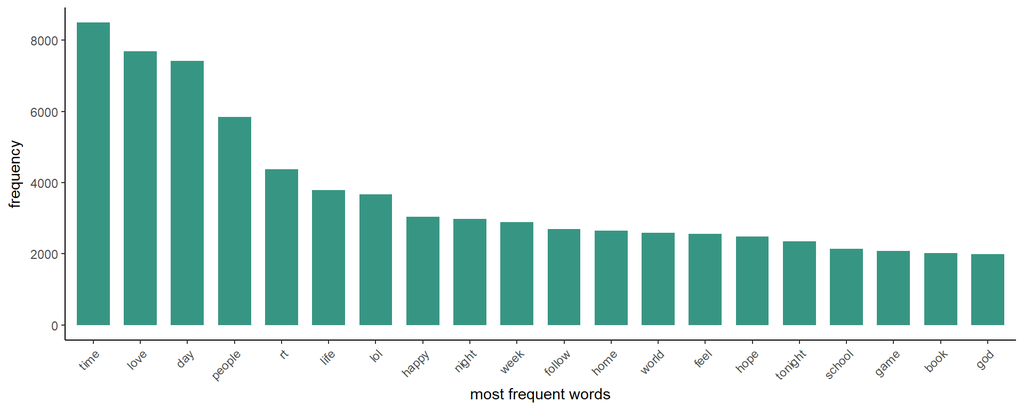

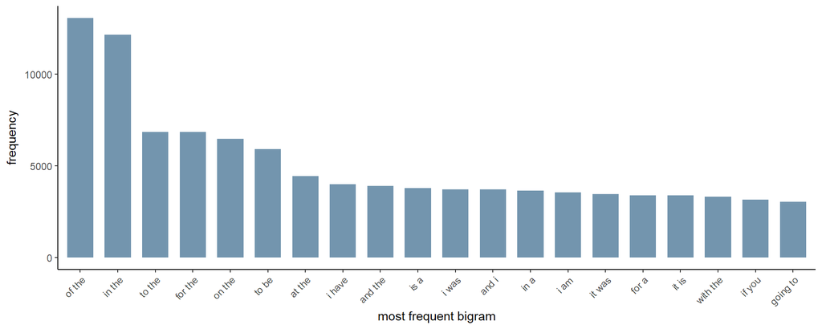

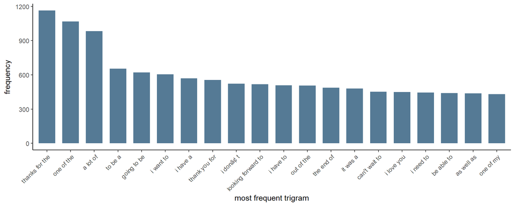

## Path Forward

The project requires to predict the next word when typing in a keyboard. The best approach to achieve this is by using n-grams and applying a prediction algorithm afterwards. I will most likely utilize the Stupid backoff algorithm as it is very well suited for this type of data.

### Appendix

Below is the R code I used to read and save the data.

```r
rm(list = ls())
library(tidyverse)
library(tidytext)
library(ggplot2)

## download the data ##
if(!file.exists("./dta/raw")){
        dir.create("./dta/raw")
}
url <- "https://d396qusza40orc.cloudfront.net/dsscapstone/dataset/Coursera-SwiftKey.zip"
download.file(url, destfile = "./dta/raw/Coursera-SwiftKey.zip", mode = "wb")
unzip(zipfile = "./dta/raw/Coursera-SwiftKey.zip", exdir = "./dta/raw")    ## unzip to open files
path <- file.path("./dta/raw" , "en_US")
files <- list.files(path, recursive = TRUE)

## open twitter data ##
con <- file("./dta/raw/final/en_US/en_US.twitter.txt", "r")
twitterDta <- readLines(con, encoding = "UTF-8", skipNul = TRUE)
twitterDta <- as.data.frame(twitterDta)
names(twitterDta)[1] <- "text"
twitterDta$source <- "twitter"  ## add an identifier to what data source it belongs
close(con)
save(twitterDta, file = "./dta/twitterDta.RData")

## open news data ##
con <- file("./dta/raw/final/en_US/en_US.news.txt", "r")
newsDta <- readLines(con, encoding = "UTF-8", skipNul = TRUE)
newsDta <- as.data.frame(newsDta)
names(newsDta)[1] <- "text"
newsDta$source <- "news"  ## add an identifier to what data source it belongs
close(con)
save(newsDta, file = "./dta/newsDta.RData")

## open blog data ##
con <- file("./dta/raw/final/en_US/en_US.blogs.txt", "r")
blogDta <- readLines(con, encoding = "UTF-8", skipNul = TRUE)
blogDta <- as.data.frame(blogDta)
names(blogDta)[1] <- "text"
blogDta$source <- "blog"  ## add an identifier to what data source it belongs
close(con)
save(blogDta, file = "./dta/blogDta.RData")

## bind data to make 1 data frame ##
textDta <- rbind(blogDta, newsDta, twitterDta)
save(textDta, file = "./dta/textDta.RData")
```